# **CMSC 320 Final Project Tutorial:**

> The goal of this tutorial is to demonstrate the Data Science pipeline by walking the reader through its various phases. These phases include data collection and parsing, data management and representation, exploratory data analysis, hypothesis testing, and communication of insights attained. The tutorial will be presented in the form of a Jupyter Notebook containing both Markdown explanations and Python code. The subject matter of the tutorial is less important than the ability to clearly communicate the approach and discuss the implications of the final results. I hope this tutorial effectively communicates ideas and concepts to the reader.

# Introduction:

> Credit cards are a popular and convenient way to make purchases within the United States. They can be used to manage finances and gather points. However they can also be a source of debt if used incorrectly. Credit cards accumulate money that needs to be paid back to the company/bank. If the statement bill is not paid for in full every month the money will acquire interest on the remaining balance and debt will accumulate. Many Americans have an unwise spending habit where they spend more than they earn. By using this data about credit card user statistics and their debt, we can use data science to make predictions and insights on credit card users.

> The data set I have chosen comes from the online source Kaggle which stores numerous datasets publicly online. This data set will provide columns such as gender, age, debt, married, customer, industry, ethnicity, yearsEmployed, Prior default, Employed, credit score, drivers license, citizenship, zip code, income, and approved. Some columns may be confusing at first glance so here is a more detailed synopsis for those columns. Married will be using a binary indicator where 0 will be single/divorced, while 1 would indicate married. The bank accounts column will have a similar indicator where 0 = does not have a bank account and 1 = does own a bank account. The industry column will be the industry of the individual's most recent job. The prior default column will have a binary indicator as well. 0 for no prior defaults and 1 for prior defaults. The employed section will also have a binary indicator 0 = not employed and 1 = employed. Here is a link to the [data set](https://www.kaggle.com/datasets/samuelcortinhas/credit-card-approval-clean-data) to download.

I will utilize many python libraries such as [pandas](https://pandas.pydata.org/), [numpys](https://numpy.org/), [matplotlib](https://matplotlib.org/stable/tutorials/introductory/pyplot.html), [seaborn](https://seaborn.pydata.org/), and [etc](https://docs.python.org/3/library/).

```python
import sqlite3
import pandas as pd
import numpy as np
import matplotlib.pyplot as plt
import seaborn as sns
from sklearn import preprocessing, svm
from sklearn.model_selection import train_test_split
from sklearn.linear_model import LinearRegression
from statsmodels.formula.api import ols
import plotly.express as px
```

# Setting Up the Data:

```python
#This is how I will get the data and table from the mirror file. This is a public data set available on kaggle.
data = pd.read_csv("/content/drive/MyDrive/ColabNotebooks/FinalTutorial/clean_dataset.csv", sep=',')
#display the data table statically to see.
data
```

|  | Gender | Age | Debt | Married | BankCustomer | Industry | Ethnicity | YearsEmployed | PriorDefault | Employed | CreditScore | DriversLicense | Citizen | ZipCode | Income | Approved |
| --- | --- | --- | --- | --- | --- | --- | --- | --- | --- | --- | --- | --- | --- | --- | --- | --- |
| 0 | 1 | 30.83 | 0.000 | 1 | 1 | Industrials | White | 1.25 | 1 | 1 | 1 | 0 | ByBirth | 202 | 0 | 1 |
| 1 | 0 | 58.67 | 4.460 | 1 | 1 | Materials | Black | 3.04 | 1 | 1 | 6 | 0 | ByBirth | 43 | 560 | 1 |
| 2 | 0 | 24.50 | 0.500 | 1 | 1 | Materials | Black | 1.50 | 1 | 0 | 0 | 0 | ByBirth | 280 | 824 | 1 |
| 3 | 1 | 27.83 | 1.540 | 1 | 1 | Industrials | White | 3.75 | 1 | 1 | 5 | 1 | ByBirth | 100 | 3 | 1 |
| 4 | 1 | 20.17 | 5.625 | 1 | 1 | Industrials | White | 1.71 | 1 | 0 | 0 | 0 | ByOtherMeans | 120 | 0 | 1 |
| ... | ... | ... | ... | ... | ... | ... | ... | ... | ... | ... | ... | ... | ... | ... | ... | ... |
| 685 | 1 | 21.08 | 10.085 | 0 | 0 | Education | Black | 1.25 | 0 | 0 | 0 | 0 | ByBirth | 260 | 0 | 0 |
| 686 | 0 | 22.67 | 0.750 | 1 | 1 | Energy | White | 2.00 | 0 | 1 | 2 | 1 | ByBirth | 200 | 394 | 0 |
| 687 | 0 | 25.25 | 13.500 | 0 | 0 | Healthcare | Latino | 2.00 | 0 | 1 | 1 | 1 | ByBirth | 200 | 1 | 0 |
| 688 | 1 | 17.92 | 0.205 | 1 | 1 | ConsumerStaples | White | 0.04 | 0 | 0 | 0 | 0 | ByBirth | 280 | 750 | 0 |
| 689 | 1 | 35.00 | 3.375 | 1 | 1 | Energy | Black | 8.29 | 0 | 0 | 0 | 1 | ByBirth | 0 | 0 | 0 |

690 rows × 16 columns

This is the data set we will be utilizing to make predictions on. There are no NaN or empty values present so it does not need any tidying up. I will want to keep all the columns I have to make a more accurate desicion tree model towards the end of the tutorial.

# **PART 1: Groups of Individuals in relation to debts**

> One important relation I would like to look at is comparing the debt of citizens and temporary residents. Citizens can also be broken up into different groups on how they achieved their citizenship. The groups they can be split into are citizenship “ByBirth” and citizenship “ByOtherMeans”. First I want to know if there is a specific group of individuals who own the majority of the debt in the United States. The groups I will distinguish between are ByBirth citizens, ByOtherMeans Citizens, and Temporary residents. To accomplish this I will create a bar chart comparing the total debt and who owns it in relation to their citizenship status.

This algorithm I will use the iterrows() function to iterate through every row in a panda dataframe. By doing this I can check the specific entry for that row's citizen column entry. Based on the values I decideed to keep variables to count of the total debt for each catagory and a total count of individuals in each category.

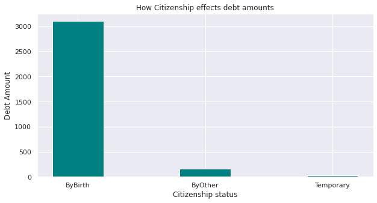

```python
#These will increase counts for the respective variables.
ByBirthDebt = 0.0;
ByBirthCount = 0;

ByOtherDebt = 0.0;
ByOtherCount = 0;

ByTempDebt = 0.0;
ByTempCount = 0;

datatypes = data.dtypes

#Go through the dataset and increment count of byBirth when the citizen ByBirth value is present. Increase the debt value as well.
for index, row in data.iterrows():
  if row['Citizen'] == 'ByBirth':
    ByBirthCount = ByBirthCount + 1
    ByBirthDebt = ByBirthDebt + row['Debt']

#Go through the dataset and increment count of byOther when the citizen ByOther value is present. Increase the debt value as well.
for index, row in data.iterrows():
  if row['Citizen'] == 'ByOtherMeans':
    ByOtherCount = ByOtherCount + 1
    ByOtherDebt = ByOtherDebt + row['Debt']

#Go through the dataset and increment count of temporary when the citizen temporary value is present. Increase the debt value as well.
for index, row in data.iterrows():
  if row['Citizen'] == 'Temporary':
    ByTempCount = ByTempCount + 1
    ByTempDebt = ByTempDebt + row['Debt']

#I want the readers to be eaily able to identify the proportion of debt in each table so each section will have 3 bars for each group I earlier identified.

#Set my x and y values here
data1 = {'ByBirth':ByBirthDebt, 'ByOther':ByOtherDebt, 'Temporary':ByTempDebt}

courses = list(data1.keys())
values = list(data1.values())
fig = plt.figure(figsize = (10, 5))

# creating the bar plot
plt.bar(courses, values, color ='teal',
        width = 0.4)

#cleaning up the graph before plotting and making more professional.
plt.xlabel("Citizenship status")
plt.ylabel("Debt Amount")
plt.title("How Citizenship effects debt amounts")
plt.show()
```

# Understanding:

> The results of this bar graph are very insightful but can lead to skewed results. The bar graph shows that the majority of the debt is owned by citizens who were given their citizenship by birth. Although this is true, it would be incorrect to make assumptions based on this data alone due to the heavy concentration of byBirth citizens in the United States. Lets go deeper and create a better analysis by developing another bar graph that divides the total debt for each section by the count of individuals in each category.

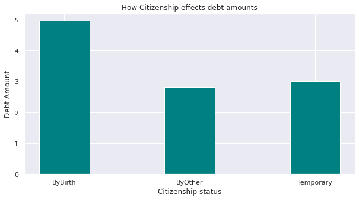

```python
data2 = {'ByBirth':ByBirthDebt /ByBirthCount, 'ByOther':ByOtherDebt/ByOtherCount, 'Temporary':ByTempDebt/ByTempCount}

courses = list(data2.keys())
values = list(data2.values())
fig = plt.figure(figsize = (10, 5))

# creating the bar plot
plt.bar(courses, values, color ='teal',
        width = 0.4)

#cleaning up the graph before plotting and making more professional.
plt.xlabel("Citizenship status")
plt.ylabel("Debt Amount")
plt.title("How Citizenship effects debt amounts")
plt.show()
```

# Understanding:

> This bar graph is much more impactful and presents data on a more even playing field. Here we can make better predictions on the population of the United States and how their citizenship status affects the debt they could potentially own. We can see that citizens who obtained their citizenship status by birth have almost double the debt amounts of those who either don't have an American citizenship or those who obtained their citizenship in a different way. It is important to always be wary of how data is portrayed throughout data science and to make sure you understand data biasness in every situation. Here we can make the conclusion that ByBirth Citizens have a much higher debt amount than the other respective groups. However, it is not as lopsided as we saw in the first bar graph.

Another important relation I would like to look at is comparing the debt of different ethnicities. First I want to know if there is a specific group of individuals who own the majority of the debt in the United States. I will create another bar graph to help display the values of debt owned by each ethnicity. Based on my knowledge about the United States, I would predict that white ethnic indivduals own most of the debt in the United States.

This algorithm I will use the iterrows() function to iterate through every row in a panda dataframe. By doing this I can check the specific entry for that row's ethnicity column entry. Based on the values I decideed to keep variables to count of the total debt for each catagory and a total count of individuals in each category.

```
['White', 'Black', 'Asian', 'Latino', 'Other']
[1746.7449999999992, 740.8249999999998, 277.245, 306.495, 277.245]
```

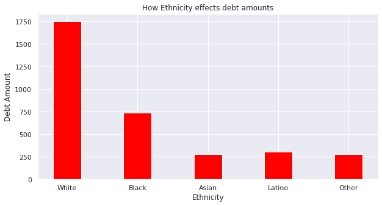

```python
#These will increase counts for the respective variables.
BlackDebt = 0.0;
BlackCount = 0;

WhiteDebt = 0.0;
WhiteCount = 0;

LatinoDebt = 0.0;
LatinoCount = 0;

AsianDebt = 0.0;
AsianCount = 0;

OtherDebt = 0.0;
OtherCount = 0;


#Go through the dataset and increment count of ethnicity when the value is present. Increase the debt value as well.
for index, row in data.iterrows():
  if row['Ethnicity'] == 'White':
    WhiteCount = WhiteCount + 1
    WhiteDebt = WhiteDebt + row['Debt']

#Go through the dataset and increment count of ethnicity when the value is present. Increase the debt value as well.
for index, row in data.iterrows():
  if row['Ethnicity'] == 'Black':
    BlackCount = BlackCount + 1
    BlackDebt = BlackDebt + row['Debt']

#Go through the dataset and increment count of ethnicity when the  is present. Increase the debt value as well.
for index, row in data.iterrows():
  if row['Ethnicity'] == 'Asian':
    AsianCount = AsianCount + 1
    AsianDebt = AsianDebt + row['Debt']

#Go through the dataset and increment count of ethnicity when the is present. Increase the debt value as well.
for index, row in data.iterrows():
  if row['Ethnicity'] == 'Latino':
    LatinoCount = LatinoCount + 1
    LatinoDebt = LatinoDebt + row['Debt']

#Go through the dataset and increment count of ethnicity when the is present. Increase the debt value as well.
for index, row in data.iterrows():
  if row['Ethnicity'] == 'Asian':
    OtherCount = OtherCount + 1
    OtherDebt = OtherDebt + row['Debt']

##I want the readers to be eaily able to identify the proportion of debt in each table so each section will have 2 bars for each group I earlier identified.

#Set my x values here
data1 = {'White':WhiteDebt, 'Black':BlackDebt, 'Asian':AsianDebt, 'Latino': LatinoDebt, 'Other':OtherDebt}

courses = list(data1.keys())
values = list(data1.values())

print(courses)
print(values)
fig = plt.figure(figsize = (10, 5))

# creating the bar plot
plt.bar(courses, values, color ='red',
        width = 0.4)

#cleaning up the graph before plotting and making more professional.
plt.xlabel("Ethnicity")
plt.ylabel("Debt Amount")
plt.title("How Ethnicity effects debt amounts")
plt.show()
```

# Understanding:

> The results of this bar graph can be utilized effectively. The bar graph shows that the majority of the debt is owned by individuals who have a white ethnic background. This can be useful in determining which ethnicity holds the most debt. We can use this data to try to tackle problems of the uneven debt coverage in the United States. However, although this is true, it would be incorrect to make assumptions based on this data alone due to the heavy concentration of white individuals in the United States. It would be smarter to make a ratio of the debt owned by one ethnicity divided by their total count of individuals. This makes a more accurate ratio and representation of what the debt statistics look like.

This next code section will display the data more effectively on the bar graph by dividing the debt amount of the ethnicity by the total number of individuals who have that ethnicity.

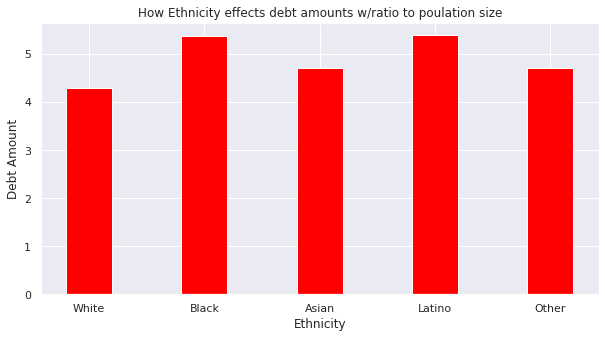

```python
#create new x and y values
data2 = {'White':WhiteDebt/WhiteCount, 'Black':BlackDebt/BlackCount, 'Asian':AsianDebt/AsianCount, 'Latino': LatinoDebt/LatinoCount, 'Other':OtherDebt/OtherCount}

#Get the keys and the values
courses = list(data2.keys())
values = list(data2.values())
fig = plt.figure(figsize = (10, 5))

# creating the bar plot
plt.bar(courses, values, color ='red',
        width = 0.4)

#cleaning up the graph before plotting and making more professional.
plt.xlabel("Ethnicity")
plt.ylabel("Debt Amount")
plt.title("How Ethnicity effects debt amounts w/ratio to poulation size")
plt.show()
```

# Understanding

> This bar graph gives a more accurate standpoint of the debt amounts per ethnicity. Because the United States population is skewed towards white individuals. This graph shows that ethnicity groups who are black and Latino have higher debt amounts on their credit card vs white individuals who were portrayed to have more debt in the first graph.

Another important relation I would like to look at is comparing the debt of different marital statuses. First I want to know if there is a specific group of individuals who own the majority of the debt in the United States. I will create another bar graph to help display the values of debt owned by those who are married and those who are not.

This algorithm I will use the iterrows() function to iterate through every row in a panda dataframe. By doing this I can check the specific entry for that row's marriage column entry. Based on the values I decideed to keep variables to count of the total debt for each catagory and a total count of individuals in each category. After I can use matplotlib's functions to create a bar chart fairly easily and visualize the data to my auidence.

```
['Married', 'Not Married']
[2607.6249999999995, 675.8949999999996]
```

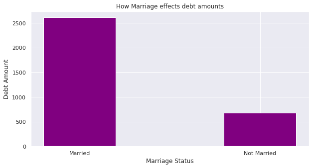

```python
#These will increase counts for the respective variables.
MarriedDebt = 0.0;
MarriedCount = 0;

NotMarriedDebt = 0.0;
NotMarriedCount = 0;


#Go through the dataset and increment count of Married when the value is present. Increase the debt value as well.
for index, row in data.iterrows():
  if row['Married'] == 1:
    MarriedCount = MarriedCount + 1
    MarriedDebt = MarriedDebt + row['Debt']

#Go through the dataset and increment count of NotMarried when the value is present. Increase the debt value as well.
for index, row in data.iterrows():
  if row['Married'] == 0:
    NotMarriedCount = NotMarriedCount + 1
    NotMarriedDebt = NotMarriedDebt + row['Debt']


#I want the readers to be eaily able to identify the proportion of debt in each table so each section will have 2 bars for each group I earlier identified.

#Set my x and y values here
data1 = {'Married':MarriedDebt, 'Not Married':NotMarriedDebt}

courses = list(data1.keys())
values = list(data1.values())

print(courses)
print(values)
fig = plt.figure(figsize = (10, 5))

# creating the bar plot
plt.bar(courses, values, color ='purple',
        width = 0.4)

plt.xlabel("Marriage Status")
plt.ylabel("Debt Amount")
plt.title("How Marriage effects debt amounts")
plt.show()
```

# Understanding:

> The results of this graph show that debt is majorly owned by individuals who are married. However, like our previous examples, it is important to note that this graph might show skewed results. The majority of the population over the age of 20 is married so there are many more individuals who are married couples. A better way to represent the data is to find the average ratio and display that data in a bar graph.

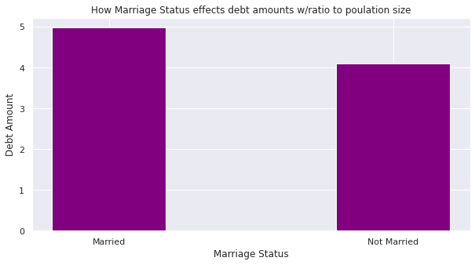

```python
#Set the new X and Y values
data2 = {'Married':MarriedDebt/MarriedCount, 'Not Married':NotMarriedDebt/NotMarriedCount}

courses = list(data2.keys())
values = list(data2.values())
fig = plt.figure(figsize = (10, 5))

# creating the bar plot
plt.bar(courses, values, color ='purple',
        width = 0.4)

plt.xlabel("Marriage Status")
plt.ylabel("Debt Amount")
plt.title("How Marriage Status effects debt amounts w/ratio to poulation size")
plt.show()
```

# Understanding

> The data portrayed in this bar graph is much more useful and portrays a better understanding of how marital status affects debt in the United States. Individuals who are married have a higher debt amount on their credit cards than those who are not married. This helps us make predictions about an individual and use statistics to make assumptions. It also allows us to better understand the United States population as a whole and similarities across the board.

# Part 2: Using Regression lines and Statistics to Analyze Predictions

# Small Introduction:

> Seaborn is a useful tool that I imported earlier above in the import statements. Using Seaborn and its tools I can create a linear regression model comparing the any data columsn to each other straight from a panda dataframe. It is extremely versatile tool that is easy to use and can be implmenetred whenever using pandas.

Suppose I fit a linear regression model of Debt vs. Age, and test for a relationship between Age and Debt. Would you reject the null hypothesis of no relationship? After plotting the graph we will see the answer to thsi question.

Using seaborn I will test the relationship between Age and Debt by looking at the slope of the linear regression line.

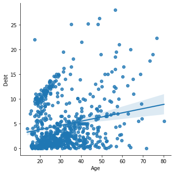

```python
#Use the seaborn feature to easily have a line of regression
sns.lmplot(x ="Age", y ="Debt", data = data)
```

# Results:

> By looking at the graph it is evident that the slope of the linear regression line is increasing. By using the Linear Regression feature for the model I will find the exact value of the slope.

```python
#Make sure to get the model coefficent for the regression line
#First get the Debt values
x = data.loc[:,"Age"].values.reshape(-1, 1)
#Get the Age values
y = data.loc[:,"Debt"].values.reshape(-1, 1)

#set the model to the linear regression
model = LinearRegression()
#fit the data
model.fit(x,y)
line = model.predict(x)
#print the coef_ to make it easier to see
print(model.coef_)
```

```
[[0.08486065]]
```

# Understanding:

The coefficent here is .084 which shows that the linear regression line has a positive slope. This means that as Age increases Debt amount slowly increases as well. Kowing this we can reject the null hypothesis stated earlier because we see a direct correlation between debt and age.

Lets print some more statistics on the relation between debt vs age. Here we can see values such as the p value, std err, and y-intercept.

```python
#Use the ols import from statmodels
#Fit a linear regression model for life expectancy including a term for an interaction between continent and year.
txt = ols(formula = 'Debt ~ Age', data = data).fit()
#print it out so I can see the results
print(txt.summary())
```

```
                            OLS Regression Results
==============================================================================
Dep. Variable:                   Debt   R-squared:                       0.041
Model:                            OLS   Adj. R-squared:                  0.039
Method:                 Least Squares   F-statistic:                     29.32
Date:                Thu, 15 Dec 2022   Prob (F-statistic):           8.48e-08
Time:                        08:27:57   Log-Likelihood:                -2071.7
No. Observations:                 690   AIC:                             4147.
Df Residuals:                     688   BIC:                             4156.
Df Model:                           1
Covariance Type:            nonrobust
==============================================================================
                 coef    std err          t      P>|t|      [0.025      0.975]
------------------------------------------------------------------------------
Intercept      2.0844      0.528      3.950      0.000       1.048       3.120
Age            0.0849      0.016      5.415      0.000       0.054       0.116
==============================================================================
Omnibus:                      154.692   Durbin-Watson:                   1.821
Prob(Omnibus):                  0.000   Jarque-Bera (JB):              278.544
Skew:                           1.338   Prob(JB):                     3.27e-61
Kurtosis:                       4.588   Cond. No.                         95.7
==============================================================================

Notes:
[1] Standard Errors assume that the covariance matrix of the errors is correctly specified.
```

# Part 3: Finding the Residuals and utilizing Violin Plots / Adding and Tidying Some Data

> Using the model coefficient and the model intercept we achieved in part 2, we can now find the expected value for each point when comparing age to debt amounts. I will call this new column the ‘residual’ value. This residual value can be either positive or negative and allows us to create very useful violin plots that can be very insightful when interpreting data.

> The expected value basically means the expected debt value of the individual at a certain age. I will gather this information by subtracyting the actual value to the expected value. I will utlize the itterows() function here to go through each row in the dataframe and will also use the panda's .at() function to set values for the new column.

```python
#How to make a violin plot of residuals vs. Age for the linear model.
#Go through each row and keep track of the index

for index, row in data.iterrows():
  #Find the expected value by taking year and multiplying the Age by the coef and adding the y-int
  ex = data.at[index, 'Age'] * model.coef_ + model.intercept_
  data.at[index, 'Expected_value'] = ex
  #set new column titled residual to actual value - expected
  data.at[index, 'residual'] = data.at[index, 'Debt'] - ex

#plot using the seaborn features
for index, row in data.iterrows():
  data.at[index, 'Age_basic'] = int(data.at[index, 'Age'])

data
```

|  | Gender | Age | Debt | Married | BankCustomer | Industry | Ethnicity | YearsEmployed | PriorDefault | Employed | CreditScore | DriversLicense | Citizen | ZipCode | Income | Approved | Expected_value | residual | Age_basic |
| --- | --- | --- | --- | --- | --- | --- | --- | --- | --- | --- | --- | --- | --- | --- | --- | --- | --- | --- | --- |
| 0 | 1 | 30.83 | 0.000 | 1 | 1 | Industrials | White | 1.25 | 1 | 1 | 1 | 0 | ByBirth | 202 | 0 | 1 | 4.700670 | -4.700670 | 30.0 |
| 1 | 0 | 58.67 | 4.460 | 1 | 1 | Materials | Black | 3.04 | 1 | 1 | 6 | 0 | ByBirth | 43 | 560 | 1 | 7.063190 | -2.603190 | 58.0 |
| 2 | 0 | 24.50 | 0.500 | 1 | 1 | Materials | Black | 1.50 | 1 | 0 | 0 | 0 | ByBirth | 280 | 824 | 1 | 4.163502 | -3.663502 | 24.0 |
| 3 | 1 | 27.83 | 1.540 | 1 | 1 | Industrials | White | 3.75 | 1 | 1 | 5 | 1 | ByBirth | 100 | 3 | 1 | 4.446088 | -2.906088 | 27.0 |
| 4 | 1 | 20.17 | 5.625 | 1 | 1 | Industrials | White | 1.71 | 1 | 0 | 0 | 0 | ByOtherMeans | 120 | 0 | 1 | 3.796056 | 1.828944 | 20.0 |
| ... | ... | ... | ... | ... | ... | ... | ... | ... | ... | ... | ... | ... | ... | ... | ... | ... | ... | ... | ... |
| 685 | 1 | 21.08 | 10.085 | 0 | 0 | Education | Black | 1.25 | 0 | 0 | 0 | 0 | ByBirth | 260 | 0 | 0 | 3.873279 | 6.211721 | 21.0 |
| 686 | 0 | 22.67 | 0.750 | 1 | 1 | Energy | White | 2.00 | 0 | 1 | 2 | 1 | ByBirth | 200 | 394 | 0 | 4.008207 | -3.258207 | 22.0 |
| 687 | 0 | 25.25 | 13.500 | 0 | 0 | Healthcare | Latino | 2.00 | 0 | 1 | 1 | 1 | ByBirth | 200 | 1 | 0 | 4.227148 | 9.272852 | 25.0 |
| 688 | 1 | 17.92 | 0.205 | 1 | 1 | ConsumerStaples | White | 0.04 | 0 | 0 | 0 | 0 | ByBirth | 280 | 750 | 0 | 3.605119 | -3.400119 | 17.0 |
| 689 | 1 | 35.00 | 3.375 | 1 | 1 | Energy | Black | 8.29 | 0 | 0 | 0 | 1 | ByBirth | 0 | 0 | 0 | 5.054539 | -1.679539 | 35.0 |

690 rows × 19 columns

# Understanding:

> The table has added a new ‘residual' column with positive and negative values in relation to the debt and expected debt values.

# Violin Plot:

> Lets now use the 'residual' column to make violin plots for the specific ages. Because the Age column is a double I will cast the data to integers so I can 1 point per age. Otherwise there would be too many values on the x axis. I also will plot a violin plot for each age section which I have detailed in the code below.

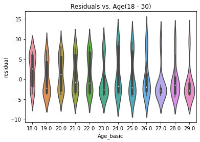

```python
table = data
#Go through each row and get the age and residual data
for index, row in table.iterrows():
  #Only plot ages between the wanted time frame by dropping all other values
  if(row['Age_basic'] > 29 or row['Age_basic'] < 18):
    table = table.drop(index)

#Use seaborns violin plot features to  facilitate the plotting process
sns.violinplot(x = 'Age_basic', y = 'residual', data = table).set(title='Residuals vs. Age(18 - 30)')
#increase figure size
sns.set(rc={'figure.figsize':(15,10)})
```

# Understanding:

> This violin plot is very useful and gives us important information in which we can create many insights with. First, we can see there is a heavy concentration of individuals who have between [0, -5] residual values. This means that there are many individuals who have debts either very close to the expected value or 5k lower. We also see that there are many outliers for each age as there is a small concentartion of individuals with high residual values, meaning a debt that is much more than the expected value. This makes sense because there should be many individuals who have a debt that are very close to the expected value.

# Continued:

> Lets use the same tatic for other age ranges.

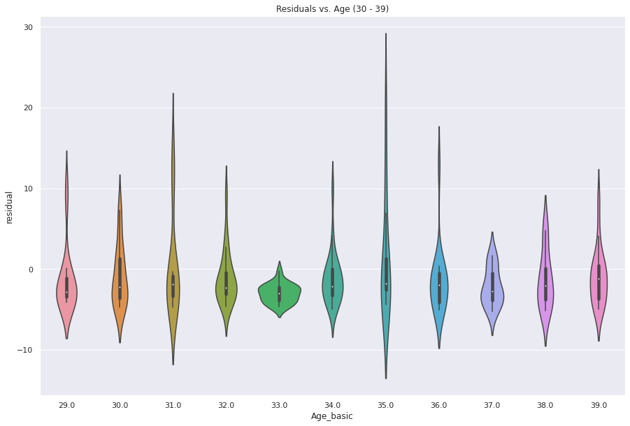

```python
table = data
#Go through each row and get the age and residual data
for index, row in table.iterrows():
   #Only plot ages between the wanted time frame by dropping all other values
  if(row['Age_basic'] < 29 or row['Age_basic'] > 39):
    table = table.drop(index)
#Use seaborns violin plot features to  facilitate the plotting process
sns.violinplot(x = 'Age_basic', y = 'residual', data = table).set(title='Residuals vs. Age (30 - 39)')
#increase figure size
sns.set(rc={'figure.figsize':(15,10)})
```

# Understanding:

> This violin plot is very useful and gives us important information in which we can create many insights with. First, we can see there is a heavy concentration of individuals who have between [0, -10] residual values. This means that there are many individuals who have debts either very close to the expected value or 10k lower. However there are individuals who have very high debts that potentially bring up the expected value. We can see how this is detailed in the violin plot as there are some individuals with debts 20k over the expected value.

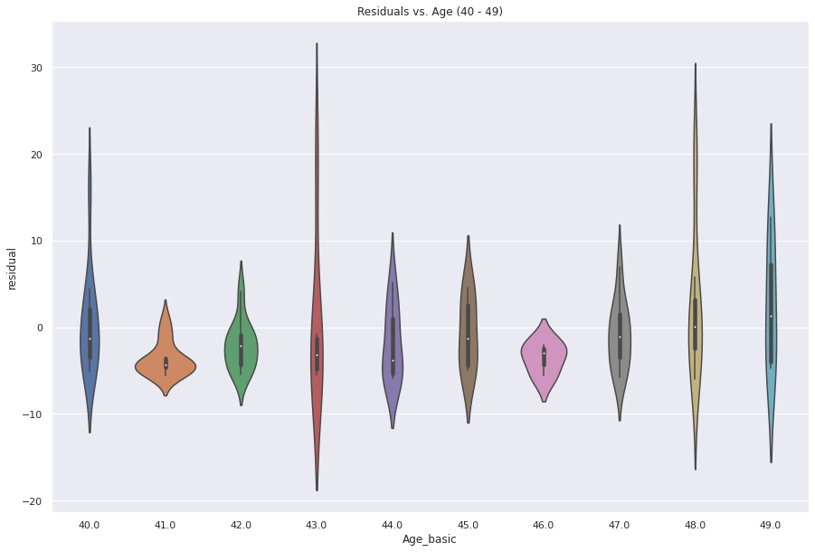

```python
table = data
#Go through each row and get the age and residual data
for index, row in table.iterrows():
   #Only plot ages between the wanted time frame by dropping all other values
  if(row['Age_basic'] < 40 or row['Age_basic'] > 49):
    table = table.drop(index)
#Use seaborns violin plot features to  facilitate the plotting process
sns.violinplot(x = 'Age_basic', y = 'residual', data = table).set(title='Residuals vs. Age (40 - 49)')
#increase figure size
sns.set(rc={'figure.figsize':(15,10)})
```

# Understanding:

> This violin plot is also very vital and gives us useful information in which we can create many insights with. First, we can see there is a heavy concentration of individuals who have between [10, -10] residual values. This means that there are many individuals who have debts either 10k over the expected value or 10k lower. However there are individuals who have very high debts that potentially bring up the expected value. We can see how this is detailed in the violin plot as there are some individuals with debts 20k and 30k over the expected value. Their debts can easily skew some data and have to be taken into account when make assumptions on the majority of the United States population and their relative debts.

# Part 4: Utilizing Seaborns Linear Regression Tools on other columns

> Earlier we used Seaborn's plotting features to find relations between Credit Card Debt and Age. Now lets use the same tool to find out if there are relations between Credit Card Debt and other values.

Lets first look at Credit Card Debt and Years Employed. My guess would be that there is a relation between years employed and debt. I would think a longher one is employed for the less debt they would have.

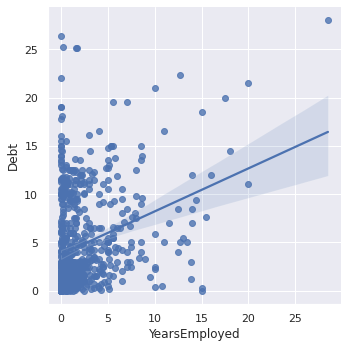

```python
#Use the seaborn feature to easily have a line of regression
sns.lmplot(x ="YearsEmployed", y ="Debt", data = data)
```

This Regression line is very interesting as it shows the opposite of what I expected. We can clearly see that as yearEmployed increases so does the average credit card debt.

This makes me curious what the avergae income is for those individuals. So this time lets plot a regression line for yearsEmployed and income.

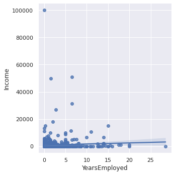

```python
#Use the seaborn feature to easily have a line of regression
sns.lmplot(x ="YearsEmployed", y ="Income", data = data)
```

There seems to be a small increase in the line of regression but I am not sure with this graph. To increase readability and produce more accurate results lets get rid of the outliers

```python
#Make sure to do this so that you are not deleting data from the main dataframe
table = data
#Go through each row
for index, row in data.iterrows():
  #Drop rows of incomes over 15000
  if row['Income'] > 15000:
    table = table.drop(index)
```

Now lets replot the graph and look at the results

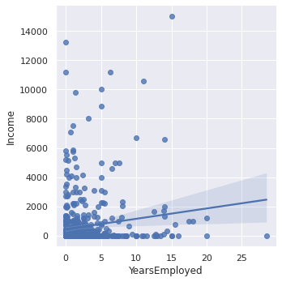

```python
#Use the seaborn feature to easily have a line of regression
sns.lmplot(x ="YearsEmployed", y ="Income", data = table)
```

So lets drop rows of individuals who have incomes over 15000 and 0.

```python
#Make sure to do this so that you are not deleting data from the main dataframe
table2 = data
#Go through each row
for index, row in data.iterrows():
   #Drop rows of incomes over 15000 and equal to 0
  if row['Income'] > 15000 or row['Income'] == 0:
    table2 = table2.drop(index)
```

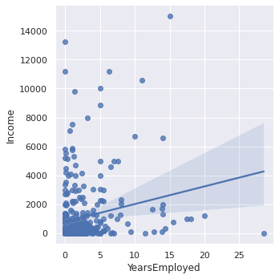

```python
#Use the seaborn feature to easily have a line of regression
sns.lmplot(x ="YearsEmployed", y ="Income", data = table2)
```

This creates a more accurate plot where we can see the correlation between years employed and income.

```python
#Make sure to get the model coefficent for the regression line
#First get teh year values
x = table2.loc[:,"YearsEmployed"].values.reshape(-1, 1)
#Also get the lifeExp values
y = table2.loc[:,"Debt"].values.reshape(-1, 1)

#set the model to the linear regression
model = LinearRegression()
#fit the data
model.fit(x,y)
line = model.predict(x)
#print the coef_ to make it easier to see
print(model.coef_)
```

```
[[0.55711142]]
```

# Part 5: Predictive Analysis and Decision Trees

> Lets use an intercation term and look at the statistics provided with it.

```python
#Use the ols import from statmodels
#Fit a linear regression model for life expectancy including a term for an interaction between continent and year.
txt = ols(formula = 'Debt ~ Age * Ethnicity', data = data).fit()
#print it out so I can see the results
print(txt.summary())
```

```
                            OLS Regression Results
==============================================================================
Dep. Variable:                   Debt   R-squared:                       0.068
Model:                            OLS   Adj. R-squared:                  0.056
Method:                 Least Squares   F-statistic:                     5.546
Date:                Thu, 15 Dec 2022   Prob (F-statistic):           2.14e-07
Time:                        08:28:13   Log-Likelihood:                -2061.6
No. Observations:                 690   AIC:                             4143.
Df Residuals:                     680   BIC:                             4189.
Df Model:                           9
Covariance Type:            nonrobust
===========================================================================================
                              coef    std err          t      P>|t|      [0.025      0.975]
-------------------------------------------------------------------------------------------
Intercept                   0.7479      2.460      0.304      0.761      -4.081       5.577
Ethnicity[T.Black]          3.2683      2.776      1.177      0.240      -2.183       8.720
Ethnicity[T.Latino]        -1.3300      2.936     -0.453      0.651      -7.094       4.434
Ethnicity[T.Other]          1.6135      3.182      0.507      0.612      -4.635       7.862
Ethnicity[T.White]          2.1086      2.562      0.823      0.411      -2.922       7.139
Age                         0.1088      0.065      1.662      0.097      -0.020       0.237
Age:Ethnicity[T.Black]     -0.0665      0.076     -0.878      0.380      -0.215       0.082
Age:Ethnicity[T.Latino]     0.0479      0.076      0.630      0.529      -0.101       0.197
Age:Ethnicity[T.Other]      0.0366      0.082      0.444      0.657      -0.125       0.199
Age:Ethnicity[T.White]     -0.0604      0.069     -0.871      0.384      -0.197       0.076
==============================================================================
Omnibus:                      154.356   Durbin-Watson:                   1.839
Prob(Omnibus):                  0.000   Jarque-Bera (JB):              284.359
Skew:                           1.314   Prob(JB):                     1.79e-62
Kurtosis:                       4.728   Cond. No.                     1.21e+03
==============================================================================

Notes:
[1] Standard Errors assume that the covariance matrix of the errors is correctly specified.
[2] The condition number is large, 1.21e+03. This might indicate that there are
strong multicollinearity or other numerical problems.
```

This may be hard to read at first so lets print out the parameters.

```python
txt.params
```

```
Intercept                  0.747872
Ethnicity[T.Black]         3.268320
Ethnicity[T.Latino]       -1.330034
Ethnicity[T.Other]         1.613489
Ethnicity[T.White]         2.108585
Age                        0.108816
Age:Ethnicity[T.Black]    -0.066533
Age:Ethnicity[T.Latino]    0.047906
Age:Ethnicity[T.Other]     0.036596
Age:Ethnicity[T.White]    -0.060444
dtype: float64
```